# Day 12: Logistic Regression — In-Class Activity (Solutions)

Is this college private?

Instructor

```r
data(College)
College <- College %>%
  mutate(tuition = Outstate / 1000, undergrad = F.Undergrad / 1000)
```

## Part 1: One Predictor

### Task 1.1: Look first

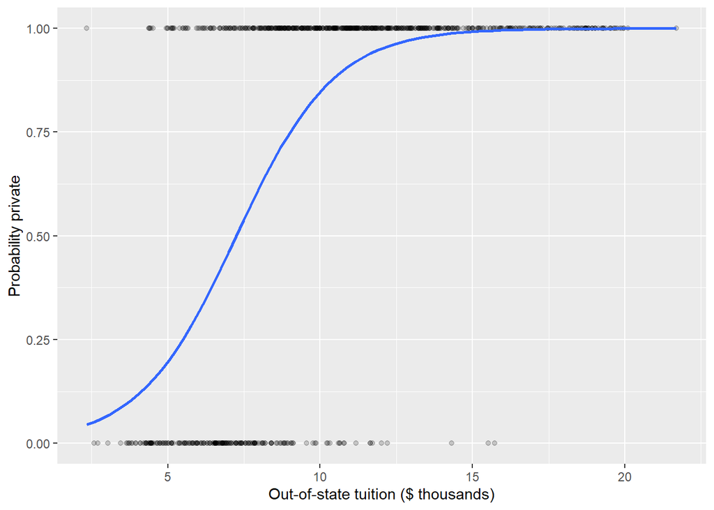

```r
ggplot(College, aes(tuition, as.numeric(Private == "Yes"))) +
  geom_point(alpha = 0.2) +
  geom_smooth(method = "glm", method.args = list(family = binomial), se = FALSE) +
  labs(x = "Out-of-state tuition ($ thousands)", y = "Probability private")
```

The chance of being private **rises** with tuition. The curve crosses 0.5 at roughly **$7,000–$7,500**: below that a college is more likely public, above it more likely private.

### Task 1.2: Fit the model

```r
fit_tuition <- glm(Private ~ tuition, data = College, family = binomial)
coef(fit_tuition)
```

```
## (Intercept)     tuition
##  -4.5220947   0.6235483
```

The `tuition` coefficient is **positive** (0.62), so higher-tuition colleges are more likely to be private.

## Part 2: Making Predictions

### Task 2.1: Predict by hand

```r
z <- coef(fit_tuition)[1] + coef(fit_tuition)[2] * 8
exp(z) / (1 + exp(z))
```

```
## (Intercept)
##   0.6145057
```

```r
predict(fit_tuition, data.frame(tuition = 8), type = "response")
```

```
##         1
## 0.6145057
```

$z = -4.52 + 0.624 \times 8 = 0.47$, so $p = e^{z} / (1 + e^{z}) \approx$ **0.61**. `predict()` gives the same number: it does exactly these two steps.

### Task 2.2: Same step, different effect

```r
predict(fit_tuition, data.frame(tuition = c(8, 12, 16)), type = "response")
```

```
##         1         2         3
## 0.6145057 0.9507567 0.9957420
```

**No.** Going from $8,000 to $12,000 raises the probability by about 34 points (61% to 95%). Going from $12,000 to $16,000 raises it by only about 4 points. At $8,000 the college is on the steep middle of the S-curve, where a change in tuition moves the probability a lot. By $12,000 the curve has already flattened out near 1, so there is little room left to rise.

## Part 3: The Graduation-Rate Puzzle

### Task 3.1: Add a second predictor

```r
fit_grad      <- glm(Private ~ Grad.Rate, data = College, family = binomial)
fit_grad_tuit <- glm(Private ~ Grad.Rate + tuition, data = College, family = binomial)

summary(fit_grad)$coefficients
```

```
##              Estimate  Std. Error   z value     Pr(>|z|)
## (Intercept) -2.082521 0.346268710 -6.014176 1.808042e-09
## Grad.Rate    0.048970 0.005576534  8.781441 1.613935e-18
```

```r
summary(fit_grad_tuit)$coefficients
```

```
##                 Estimate  Std. Error    z value     Pr(>|z|)
## (Intercept) -4.621449728 0.488695279 -9.4567104 3.177834e-21
## Grad.Rate    0.002616676 0.006950679  0.3764634 7.065724e-01
## tuition      0.616683692 0.052671788 11.7080455 1.159210e-31
```

On its own, `Grad.Rate` has a positive, highly significant coefficient (0.049). Once `tuition` is added, it shrinks to about 0.003 and its p-value rises to 0.71: no longer significant.

This is omitted variable bias. Expensive colleges tend to have **high** graduation rates (correlation 0.57), and expensive colleges are usually private. Without `tuition` in the model, `Grad.Rate` takes credit for tuition’s effect: high graduation rates “predict” private only because they go with high tuition.

**No.** Once you know a college’s tuition, its graduation rate adds almost nothing about whether it’s private.

## Part 4: Classify the Colleges

### Task 4.1: From probabilities to labels

```r
fit_two <- glm(Private ~ tuition + undergrad, data = College, family = binomial)
p_two   <- predict(fit_two, type = "response")
pred    <- ifelse(p_two > 0.5, "Yes", "No")

table(Actual = College$Private, Predicted = pred)
```

```
##       Predicted
## Actual  No Yes
##    No  184  28
##    Yes  21 544
```

```r
mean(pred != College$Private)
```

```
## [1] 0.06306306
```

```r
# Baseline: call every college private
mean(College$Private != "Yes")
```

```
## [1] 0.2728443
```

The error rate is **6.3%**. Labeling every college private would be wrong for every public college: **27.3%** of colleges. The model cuts the error rate by about 77%.

The more common mistake is calling a **public college private** (28 colleges, versus 21 private colleges called public). That makes sense: some public universities charge high out-of-state tuition, and the model mainly goes by tuition and size.

## Bonus

### Bonus 1: Why not linear regression?

```r
lpm <- lm(I(Private == "Yes") ~ tuition, data = College)
range(fitted(lpm))
```

```
## [1] 0.2311691 1.4165404
```

```r
mean(fitted(lpm) > 1)
```

```
## [1] 0.1557272
```

About 16% of colleges get a “probability” above 1. They are the most expensive colleges: the straight line keeps rising past 1 as tuition grows, while a probability can’t.

### Bonus 2: Odds

```r
exp(coef(fit_tuition))
```

```
## (Intercept)     tuition
##  0.01086624  1.86553577
```

Each extra $1,000 of tuition multiplies the odds that a college is private by about **1.87**. Because the log-odds are linear in tuition, this multiplier is the same wherever you start. The probability changes by different amounts (Task 2.2) because turning odds into a probability squeezes everything into 0 to 1: near 1 there’s little room left, even though the odds keep multiplying by the same factor.

### Bonus 3: Choosing the cutoff

```r
pred_80 <- ifelse(p_two > 0.8, "Yes", "No")
table(Actual = College$Private, Predicted = pred_80)
```

```
##       Predicted
## Actual  No Yes
##    No  204   8
##    Yes  56 509
```

```r
mean(pred_80 != College$Private)
```

```
## [1] 0.08236808
```

Public colleges called private fall from 28 to 8. The cost: private colleges called public rise from 21 to 56, and the overall error rate goes up to 8.2%. A stricter cutoff trades one kind of mistake for the other. Whether it’s worth it depends on which mistake hurts the site’s users more.

### Bonus 4: More predictors

```r
fit_more <- glm(Private ~ tuition + undergrad + perc.alumni + S.F.Ratio,
                data = College, family = binomial)
summary(fit_more)$coefficients
```

```
##                Estimate Std. Error   z value     Pr(>|z|)
## (Intercept) -2.32086239 0.97244396 -2.386628 1.700367e-02
## tuition      0.65295804 0.07390346  8.835283 9.984497e-19
## undergrad   -0.56047673 0.06025160 -9.302271 1.374777e-20
## perc.alumni  0.04823161 0.01817544  2.653670 7.962175e-03
## S.F.Ratio   -0.06993240 0.04213319 -1.659794 9.695595e-02
```

```r
pred_more <- ifelse(predict(fit_more, type = "response") > 0.5, "Yes", "No")
table(Actual = College$Private, Predicted = pred_more)
```

```
##       Predicted
## Actual  No Yes
##    No  182  30
##    Yes  19 546
```

```r
mean(pred_more != College$Private)
```

```
## [1] 0.06306306
```

`perc.alumni` is significant at the 5% level (p-value 0.008); `S.F.Ratio` is not (0.097). But the error rate is 6.3% with them, against 6.3% without: 49 mistakes versus 49, just shuffled between the two kinds.

So a significant coefficient doesn’t have to mean better classifications. Significance says the predictor is related to the odds of being private, holding tuition and size fixed. Tuition and size already classify about 94% of colleges correctly, and `perc.alumni` doesn’t push many colleges across the 0.5 cutoff. With no gain in accuracy, the simpler two-predictor model is the better choice.